# 分類(Classification)

Yao-Jen Kuo

June, 2016

# 摘要

- 決策樹
- k最近鄰分類法(k-Nearest Neighbors)
- ROC曲線

# 分類的特性

- 自動依據已知資料為未知資料做預測分類
- 一個人整體平均而言是開心還是不開心?
  - 數值型變數
    - 身高
    - 體重
    - 年收入
    - 年紀
    - …
  - 類別型變數
    - 感情狀態
    - 出生地
    - 有無運動習慣
    - 有無房
    - 有無車
    - …

# 決策樹的外型與名稱

- 節點(Nodes)
  - 根(Root)
  - 葉(Leafs)
- 枝(Edges)
- 以Titanic資料集的決策樹為例:

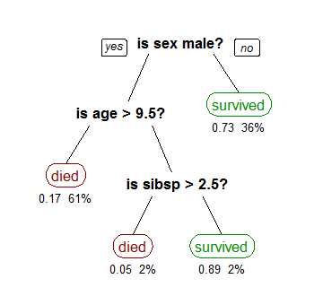

Source: Google Search

# 一個決策樹是怎麼產生的

- 決策樹終極的目標其實是希望每一**葉**(Leaf)都只有一種分類
- 但是在實務上幾乎是不可能的
- 在每一個節點上面有兩件事情要決定:
  - 選一個變數來切分資料
  - 決定變數的切分門檻
- 常用的決定指標叫做**資訊獲利(Information Gain)**
  - 如果資料集切分得好, 資訊獲利值高
  - 資料集切分得不好, 資訊獲利值低
  - 在每個節點上, 都要選擇最高資訊獲利值的變數與切分門檻
- 而 `rpart()` 預設是用另一個常用的指標叫做**吉尼不純度(Gini Impurity)**
  - 如果資料集切分得好, 吉尼不純度低
  - 資料集切分得不好, 吉尼不純度高
  - 在每個節點上, 都要選擇最低吉尼不純度的變數與切分門檻

# 一個決策樹是怎麼產生的 - Hands on

- 每個節點中都有三行資訊
  - 第一個數字告訴你這個節點資料中最多的類別是什麼
  - 第二組數字告訴你類別的比例
  - 第三個數字告訴你這個節點佔所有訓練資料的比例

```r
library(rpart)
library(rattle)
```

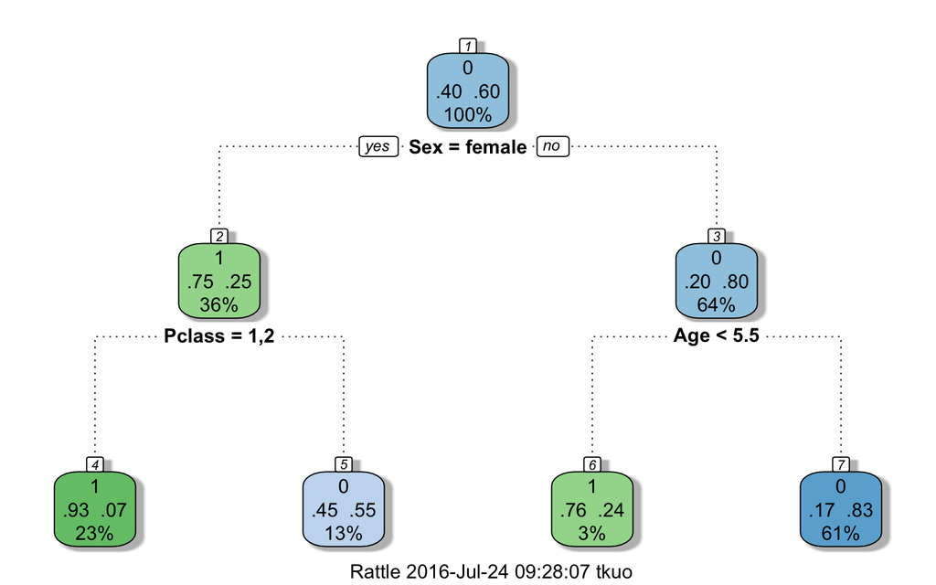

```r
library(rpart.plot)
library(RColorBrewer)
library(magrittr)

# 載入titanic資料集
titanic <- read.csv("/Users/tkuo/ntu_train/NTUTrainRL3/data/train.csv", header = TRUE)
titanic <- titanic[, c(2, 3, 5, 6)] %>% na.omit
titanic$Survived <- factor(titanic$Survived, levels = c("1", "0"))
titanic$Pclass <- factor(titanic$Pclass)

# 建立訓練與測試樣本
n <- nrow(titanic)
set.seed(123)
shuffledTitanic <- titanic[sample(n), ]
trainIndices <- 1:round(0.7 * n)
train <- shuffledTitanic[trainIndices, ]
testIndices <- (round(0.7 * n) + 1):n
test <- shuffledTitanic[testIndices, ]

# 建立決策樹模型
tree <- rpart(Survived ~ ., data = train, method = "class")

# 畫決策樹
fancyRpartPlot(tree)
```

```r
# 預測測試樣本
prediction <- predict(tree, test, type = "class")

# 計算accuracy
confusionMatrix <- table(test$Survived, prediction)
accuracy <- sum(diag(confusionMatrix)) / sum(confusionMatrix)
accuracy
```

```
## [1] 0.7757009
```

# 一個決策樹是怎麼產生的 - Do It Yourself

- 加入`SibSp`, `Fare`, `Cabin`與`Embarked`再玩一次!

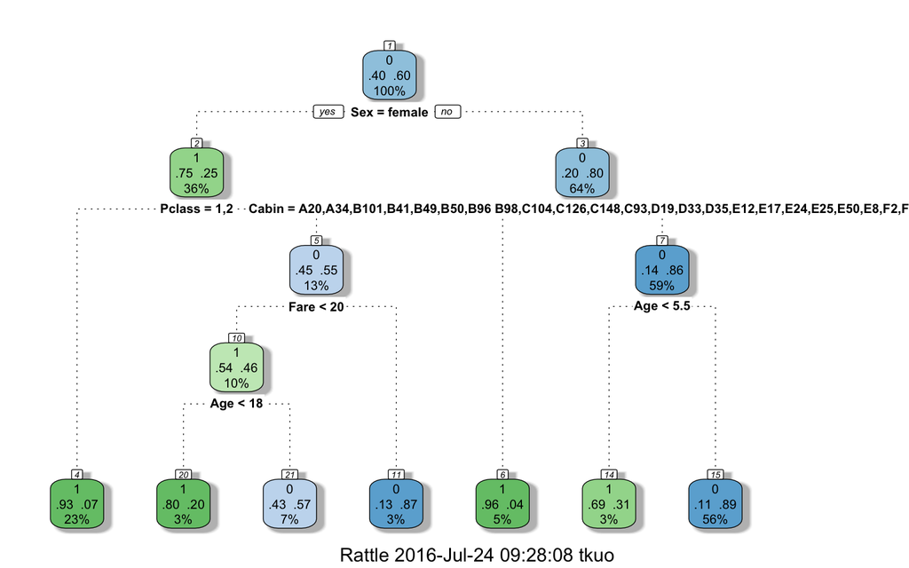

```r
# 載入titanic資料集
titanic <- read.csv("/Users/tkuo/ntu_train/NTUTrainRL3/data/train.csv", header = TRUE)
titanic <- titanic[, c(2, 3, 5, 6, 7, 10:12)] %>% na.omit
titanic$Survived <- factor(titanic$Survived, levels = c("1", "0"))
titanic$Pclass <- factor(titanic$Pclass)

# 建立訓練與測試樣本
n <- nrow(titanic)
set.seed(123)
shuffledTitanic <- titanic[sample(n), ]
trainIndices <- 1:round(0.7 * n)
train <- shuffledTitanic[trainIndices, ]
testIndices <- (round(0.7 * n) + 1):n
test <- shuffledTitanic[testIndices, ]

# 建立決策樹模型
tree <- rpart(Survived ~ ., data = train, method = "class")

# 畫決策樹
fancyRpartPlot(tree)
```

```r
# 預測測試樣本
prediction <- predict(tree, test, type = "class")

# 計算accuracy
confusionMatrix <- table(test$Survived, prediction)
accuracy <- sum(diag(confusionMatrix)) / sum(confusionMatrix)
accuracy
```

```
## [1] 0.7897196
```

# 修剪(pruning)是什麼?

- 你還記得我們上一個章節教的Overfitting嗎?
- 修剪就是為了要避免Overfitting的情況產生!

# 修剪(pruning)是什麼? - Hands on

- `rpart()`有一個參數是`control = rpart.control`, 輸入 `?rpart.control`
- `rpart.control(cp = )` 是complexity parameter, 如果 `cp` 值愈小, accuracy就會愈高, 但也愈可能Overfitting
- `prune()`函數可以針對Overfitting的決策樹模型修改 `cp`

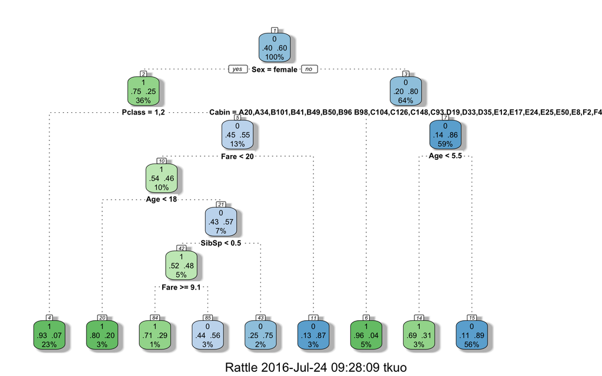

```r
# 建立一個Overfitting的決策樹模型(cp = 0.00001)
set.seed(123)
treeComplex <- rpart(Survived ~ ., train, method = "class", control = rpart.control(cp = 0.00001))

# 作圖
fancyRpartPlot(treeComplex)
```

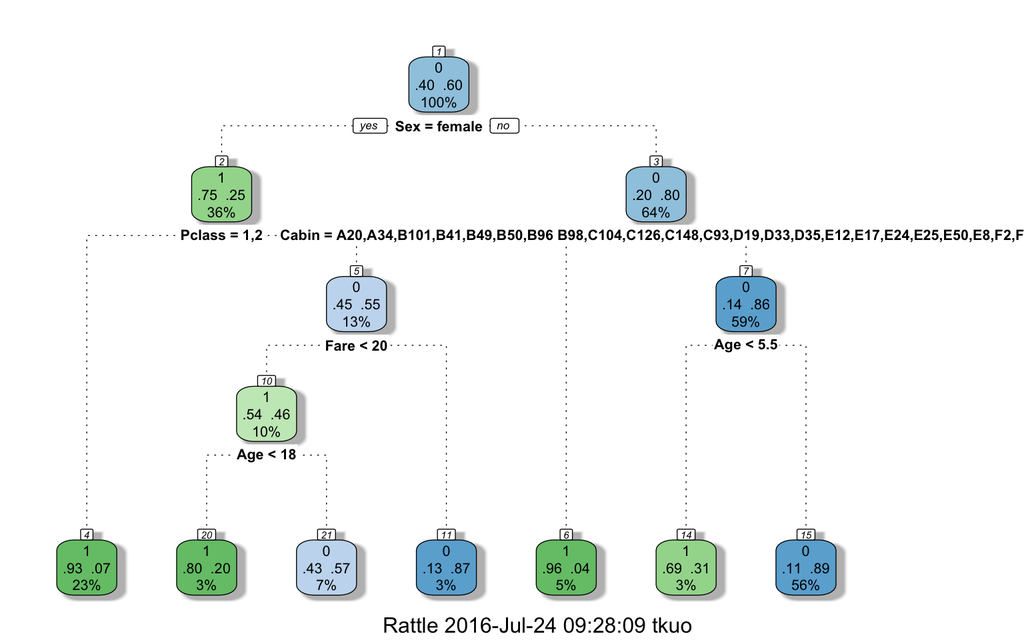

```r
# 修剪
treePruned <- prune(treeComplex, cp=0.01)

# 作圖
fancyRpartPlot(treePruned)
```

# 修剪(pruning)是什麼? - Do It Yourself

- 把前一個加入加入`SibSp`, `Fare`, `Cabin`與`Embarked`的決策樹模型 `cp` 指定為 0.00001, 並使用`prune()`函數進行修剪為預設的cp = 0.01

```r
titanic <- read.csv("/Users/tkuo/ntu_train/NTUTrainRL3/data/train.csv", header = TRUE)
titanic <- titanic[, c(2, 3, 5, 6, 7, 10:12)] %>% na.omit
titanic$Survived <- factor(titanic$Survived, levels = c("1", "0"))
titanic$Pclass <- factor(titanic$Pclass)

# 建立訓練與測試樣本
n <- nrow(titanic)
set.seed(123)
shuffledTitanic <- titanic[sample(n), ]
trainIndices <- 1:round(0.7 * n)
train <- shuffledTitanic[trainIndices, ]
testIndices <- (round(0.7 * n) + 1):n
test <- shuffledTitanic[testIndices, ]

# 建立決策樹模型
tree <- rpart(Survived ~ ., data = train, method = "class", control = rpart.control(cp = 0.00001))
# 修剪
treePruned <- prune(tree, cp=0.01)
```

# 改用資訊獲利(Information Gain)試試看 - Hands on

- 前面我們使用預設的**吉尼不純度(Gini Impurity)**作為切分資料集的決定指標
- 若想改為使用**資訊獲利(Information Gain)**在建立模型的時候要多指定一個參數 `parms = list(split = "information")`
- 輸入 `?rpart` 看看 `parms` 的參數說明

```r
# 建立
set.seed(123)
treeIG <- rpart(Survived ~ ., train, method = "class", parms = list(split = "information"))
predictionIG <- predict(treeIG, test, type = "class")
confusionMatIG <- table(test$Survived, predictionIG)
accuracyIG <- sum(diag(confusionMatIG)) / sum(confusionMatIG)
accuracyIG
```

```
## [1] 0.7523364
```

# k最近鄰分類法(k-Nearest Neighbors)

- 用一個二元分類的圖例說明
- k = 1

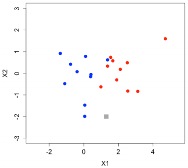

Source: DataCamp

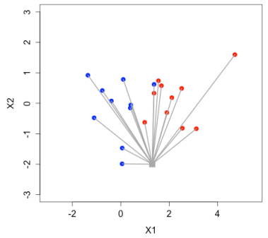

Source: DataCamp

- 如果 k = 5 就會從最近的 5 個點中哪個顏色較多決定新的資料點屬於什麼顏色，所以 k-nn 的 k 應該是一個奇數
- 計算距離的方式常見有兩種:
  - 歐幾里得距離(Eucledian Distiance)
  - 曼哈頓距離(Manhattan Distance)

$$d_E(a, b) = \sqrt {\sum_{i=1} ^ D (a_i - b_i) ^ 2}$$

$$d_M(a, b) = \sum_{i = 1} ^ D \vert{a_i - b_i}\vert$$

# 單位標準化

- 既然這個演算法使用距離作分類, 我們必須對這些變數的單位進行**標準化**

| height(m) | weight(kg) |
| --- | --- |
| 1.92 | 92 |
| 1.92 | 91 |
| 2.03 | 92 |

| height(cm) | weight(kg) |
| --- | --- |
| 192 | 92 |
| 192 | 91 |
| 203 | 92 |

- 標準化公式
  - Min Max Method

$$\frac{x - min(x)}{max(x) - min(x)}$$

# 單位標準化 - Hands on

- 將 `titanic` 資料集的 Pclass 標準化

```r
titanic <- read.csv("/Users/tkuo/ntu_train/NTUTrainRL3/data/train.csv", header = TRUE)
titanic <- titanic[, c(2, 3, 6)] %>% na.omit
titanic$Survived <- factor(titanic$Survived, levels = c("1", "0"))

# 標準化Pclass
minPclass <- min(titanic$Pclass)
maxPclass <- max(titanic$Pclass)
titanic$Pclass <- (titanic$Pclass - minPclass) / (maxPclass - minPclass)
```

# 單位標準化 - Do It Yourself

- 將`titanic` 資料集的 Age 也進行標準化

```r
# 標準化Age
minAge <- min(titanic$Age)
maxAge <- max(titanic$Age)
titanic$Age <- (titanic$Age - minAge) / (maxAge - minAge)
```

# k最近鄰分類法(k-Nearest Neighbors) - Hands on

- `knn()` 函數在 `class` 套件中, 使用前要安裝與載入
- 使用 `install.packages()` 與 `library()` 進行安裝和載入
- `knn()` 函數我們主要使用 4 個參數:
  - `train`
  - `test`
  - `cl`
  - `k`

```r
# 切分訓練測試樣本
set.seed(123)
n <- nrow(titanic)
shuffledTitanic <- titanic[sample(n), ]
trainIndices <- 1:round(0.7 * n)
train <- shuffledTitanic[trainIndices, ]
testIndices <- (round(0.7 * n) + 1):n
test <- shuffledTitanic[testIndices, ]

# 先將標準答案獨立出來
trainLabels <- train$Survived
testLabels <- test$Survived

# 獨立預測變數
knnTrain <- train[, -c(1)]
knnTest <- test[, -c(1)]

# 建立模型
library(class)
set.seed(123)
pred <- knn(train=knnTrain, test=knnTest, cl=trainLabels, k=5)
```

# k最近鄰分類法(k-Nearest Neighbors) - Do It Yourself

- 建立混淆矩陣並將accuracy計算印出

```r
confusionMatrix <- table(testLabels, pred)
accuracy <- sum(diag(confusionMatrix)) / sum(confusionMatrix)
accuracy
```

```
## [1] 0.6915888
```